# memnet

Dirk U. Wulff

2018-10-31

The `memnet` package provides efficient implementations of network science tools to facilitate research into human (semantic) memory. In its current version, the package contains several methods to **infer networks from verbal fluency data**, various **network growth models**, diverse **(switcher-) random walk processes**, and tools to analyze and visualize networks.

The majority of `memnet` is written in C++ to deliver maximum performance.

Have questions, found annoying errors, or have need/recommendation for additional functionality? Please don’t hesitate to write me at `dirk.wulff@gmail.com` or `https://github.com/dwulff/memnet`. Thanks!

## Networks from verbal fluency data

Verbal fluency is a commonly employed task in cognitive science and neuropsychological diagnosis that requires individuals to retrieve within a limited time window, e.g., 1 minute, as many elements from a natural category as they can. Typically, researchers interpret the sequences that individuals produce in this task as reflecting the underlying semantic network structure. Several methods have been proposed to infer the network structure from verbal fluency including the three methods implement here: `community_graph`, `threshold_graph`, and `rw_graph`. Of these three, `community_graph` is the most complex. It adds edges for each pair of produced elements that occur within a window of `l` steps and then retains only those that occur more often than `min_cooc` and what is expected by chance giving a false positive rate of `crit`. `threshold_graph` and `rw_graph` are both nested within `community_graph`. The former retains `min_cooc` as a parameter but sets `l = 1` and `crit = 1`, implying that only adjacent nodes are considered and that chance expectations are not directly taken into account. The latter sets all parameters to 1 by including edges for every adjacent pair of nodes. The results are illustrated below.

```r
library(memnet)

# get data
data("animal_fluency")
age = as.numeric(names(animal_fluency))

# infer networks for age > 70
net_comunity = community_graph(animal_fluency[age > 70])
net_threshold = threshold_graph(animal_fluency[age > 70])
net_rw = rw_graph(animal_fluency[age > 70])

# show stats
network_stats(edg_to_adj(net_comunity))
```

```
#>         |V|         |E|           k           C          Cc           L
#>  91.0000000 170.0000000   1.8681319   0.2890767  14.0814358   3.6721981
#>          Lc           S           A           p
#>   4.1809481   3.3680006  -0.2343542   0.9780220
```

```r
network_stats(edg_to_adj(net_threshold))
```

```
#>          |V|          |E|            k            C           Cc
#>  70.00000000 152.00000000   2.17142857   0.31567992  10.17652372
#>            L           Lc            S            A            p
#>   3.07778295   3.63950362   2.79612958   0.06264176   0.94285714
```

```r
network_stats(edg_to_adj(net_rw))
```

```
#>         |V|         |E|           k           C          Cc           L
#> 209.0000000 747.0000000   3.5741627   0.1788195  10.4565117   3.0591645
#>          Lc           S           A           p
#>   3.7885372   2.7600393   0.0781339   1.0000000
```

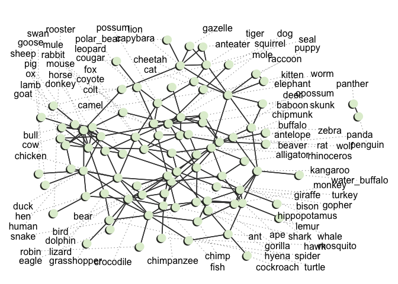

```r
# plot
network_plot(edg_to_adj(net_comunity), nod_cex = 2, lab_cex = 1)
```

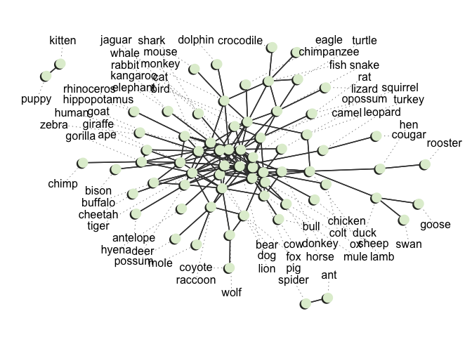

```r
network_plot(edg_to_adj(net_threshold), nod_cex = 2, lab_cex = 1)
```

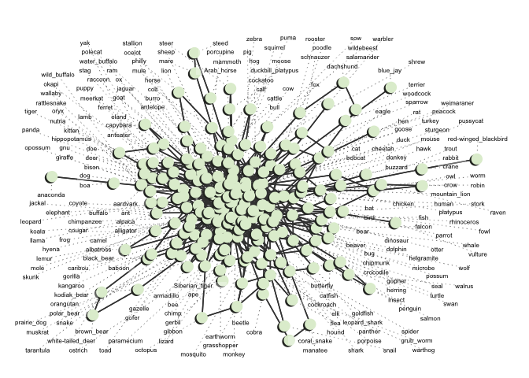

```r
network_plot(edg_to_adj(net_rw), nod_cex = 2, lab_cex = .5, lab_lwd = 1, lab_grid_size = 70)
```

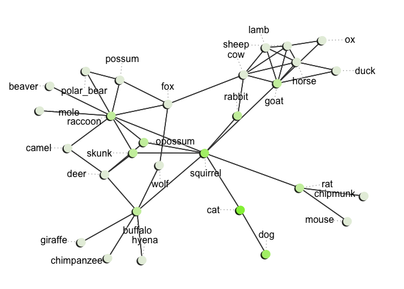

```r
# inspect neighborhood of cat
neighborhood_plot(edg_to_adj(net_comunity), k = 3, node = 'cat', nod_cex = 2, lab_cex = 1)
```

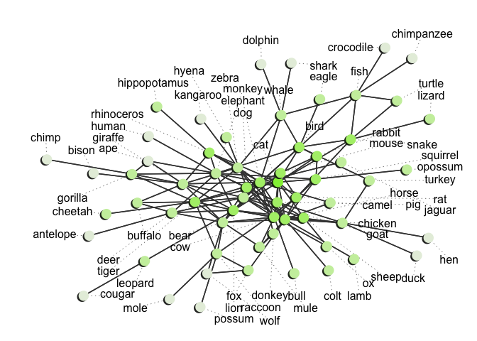

```r
neighborhood_plot(edg_to_adj(net_threshold), k = 3, node = 'cat', nod_cex = 2, lab_cex = 1)
```

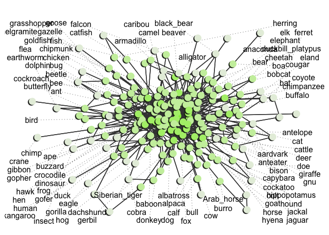

```r
neighborhood_plot(edg_to_adj(net_rw), k = 3, node = 'cat', nod_cex = 2, lab_cex = 1)
```

The networks were plotted using the plotting functions currently available in `memnet`: `network_plot` and `neighborhood` plot, which plot the entire network or the k- neighborhood of a specific node, respectively.

## Network growth models

A key question in research on semantic networks is their developmental trajectory and memory growth models one possible answer. `memnet` implements a total of five network growth models:

The `grow_ba` grows networks with scale-free degree distributions using a process known as preferential attachment, which connects incoming nodes preferably with nodes that are already highly connected. `grow_st` and `grow_hk` share this aspect of preferential attachment, but add to triad formation process that connects incoming nodes to neighbors of previously connected nodes, in order to account for the high clustering of naturally occurring (memory) networks. `grow_ws` mixes regular lattices (`grow_lattices`) with a random graph in order to simultaneously create high clustering and low average shortest path lengths, a property combination known as small-world.

```
#> labeled nodes 1:network_size
```

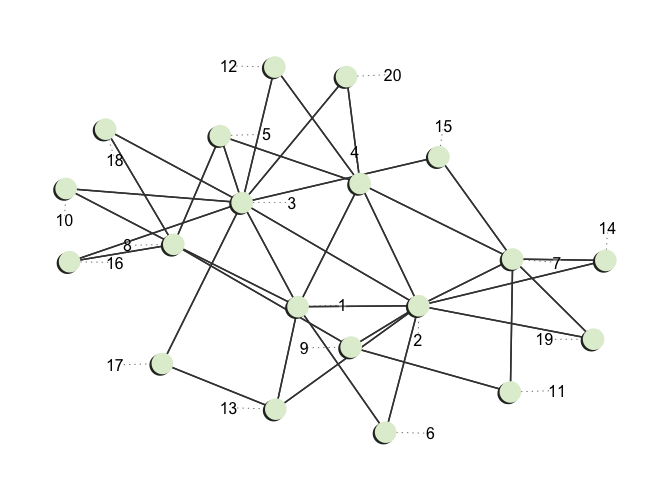

```r
# plot networks of different growth mechanisms
network_plot(grow_st(20, 2))
```

```
#> labeled nodes 1:network_size
```

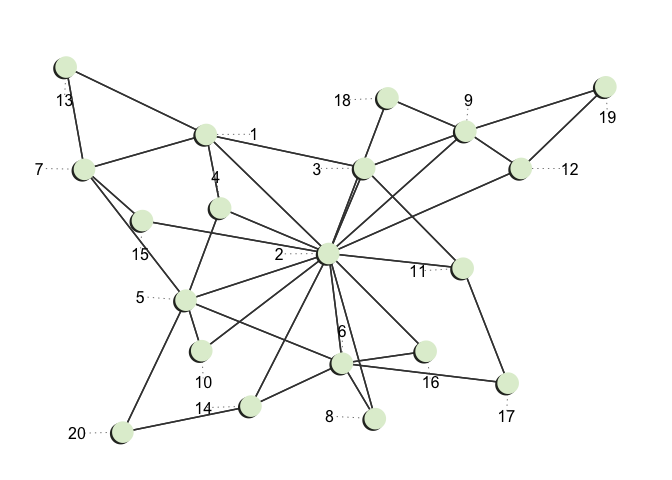

```r
network_plot(grow_hk(20, 2, p = .3))
```

```
#> labeled nodes 1:network_size
```

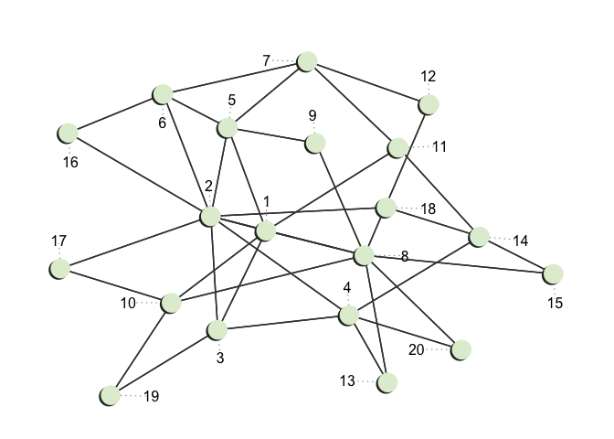

```r
network_plot(grow_ba(20, 2))
```

```
#> labeled nodes 1:network_size
```

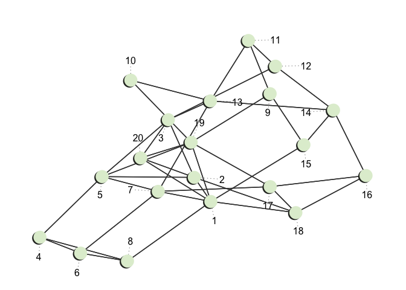

```r
network_plot(grow_ws(20, 4, p = .5))
```

```
#> labeled nodes 1:network_size
```

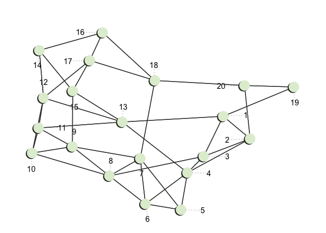

```r
network_plot(grow_ws(20, 4))
```

## Simulate memory access using switcher-random walks

Access from memory is often understood as a switcher-random process operating on an underlying memory network. `memnet` contains various functions to implement such switcher-random walk processes that allow simulation of behavioral data. `fluency` and its fast, imprecise sibling `ffluency` produce sequences of memory responses based on a censored, switcher-random walk that emits responses only for first visits to a node. `search_rw` and its repeated version `search_rw_mean` use switcher-random walk processes to determine the (average) distance between nodes taken account of the entire network structure rather than only the direct path.

```r
# extract adjlist from community network
adjlist = edg_to_adjlist(net_comunity)

# simulate fluency sequences
f = fluency(adjlist, c(10, 14, 16, 18))
restore_names(f, get_names(net_comunity))
```

```
#> [[1]]
#>  [1] "spider"      "rat"         "dog"         "ox"          "lemur"
#>  [6] "zebra"       "fox"         "grasshopper" "gazelle"     "human"
#>
#> [[2]]
#>  [1] "horse"     "sheep"     "hyena"     "goat"      "turkey"
#>  [6] "ox"        "kangaroo"  "mouse"     "tiger"     "hen"
#> [11] "crocodile" "raccoon"   "bull"      "colt"
#>
#> [[3]]
#>  [1] "goat"         "penguin"      "robin"        "mosquito"
#>  [5] "ox"           "hen"          "squirrel"     "anteater"
#>  [9] "hippopotamus" "whale"        "zebra"        "rabbit"
#> [13] "chicken"      "donkey"       "elephant"     "sheep"
#>
#> [[4]]
#>  [1] "wolf"       "eagle"      "mouse"      "cheetah"    "anteater"
#>  [6] "raccoon"    "panda"      "sheep"      "fish"       "cow"
#> [11] "fox"        "lion"       "gazelle"    "bear"       "beaver"
#> [16] "puppy"      "rhinoceros" "chipmunk"
```

```r
# simulate fluency sequences
s = search_rw_mean(adjlist, 1:5, 1:5, nrep = 100)
restore_names(s, get_names(net_comunity))
```

```
#>       [,1]           [,2]           [,3]
#>  [1,] "alligator"    "alligator"    "217.93"
#>  [2,] "alligator"    "hippopotamus" "184.78"
#>  [3,] "alligator"    "rhinoceros"   "358.61"
#>  [4,] "alligator"    "ant"          "356.18"
#>  [5,] "alligator"    "ape"          "75.38"
#>  [6,] "hippopotamus" "alligator"    "237.54"
#>  [7,] "hippopotamus" "hippopotamus" "84.7"
#>  [8,] "hippopotamus" "rhinoceros"   "401.92"
#>  [9,] "hippopotamus" "ant"          "386.49"
#> [10,] "hippopotamus" "ape"          "43.08"
#> [11,] "rhinoceros"   "alligator"    "271.25"
#> [12,] "rhinoceros"   "hippopotamus" "228.95"
#> [13,] "rhinoceros"   "rhinoceros"   "166.64"
#> [14,] "rhinoceros"   "ant"          "412.3"
#> [15,] "rhinoceros"   "ape"          "107.93"
#> [16,] "ant"          "alligator"    "255.59"
#> [17,] "ant"          "hippopotamus" "235.99"
#> [18,] "ant"          "rhinoceros"   "315.83"
#> [19,] "ant"          "ant"          "323.26"
#> [20,] "ant"          "ape"          "84.31"
#> [21,] "ape"          "alligator"    "255.81"
#> [22,] "ape"          "hippopotamus" "189.21"
#> [23,] "ape"          "rhinoceros"   "330.02"
#> [24,] "ape"          "ant"          "398.02"
#> [25,] "ape"          "ape"          "55.23"
```